# Tenth Week: Principal Component Analysis and Factor Analysis

PCA Stock, image, …

Aida Ramezani 95105595

2018-05-19 19:31:21

۱.در این سوال سود را برابر با تفاضل اولین مقدار Open و آخرین مقدار آن در طی بازه گفته شده در نظر گرفتیم. همچنین انتهای هر ماه را تا انتهای همان ماه در سال بعد (یا دوسال بعد یا پنج سال بعد) را بازه در نظر گرفتیم.

[interactive chart not shown]

۲. برای این سوال تفاضل Open و lag(Open) را برابر با سود در نظر گرفتیم و با استفاده از آزمون غیر پارامتریک Wilcoxon این جمله را بررسی کردیم. مشاهده میشود که با توجه به p-value به دست آمده و فرض صفر برابر با عبارت صورت سوال، توانستیم به راحتی این فرض را رد کنیم.

```
## [1] 48.34
```

```
##
##  Wilcoxon signed rank test with continuity correction
##
## data:  stock13$prof
## V = 1076500000, p-value = 7.672e-11
## alternative hypothesis: true location is greater than 0
```

۳. گردش مالی را برابر با ضرب Volume در Adj Close در نظر گرفتیم. دلیل این اتفاق این است که در آن روز  
کالاهای اصلی صادرات و واردات از جمله نفت افت شدید قیمت داشته اند، در نتیجه سهام شرکت ها کاهش یافته و در پی آن مبادلات انجام شده برای خرید سهام افزایش یافته است. این روز به روز stock market selloff شهرت دارد.

```
## # A tibble: 1 x 13
## # Groups:   Date [1]
##   Date        Open  High   Low Close  Volume `Adj Close` industaryName
##   <date>     <dbl> <dbl> <dbl> <dbl>   <int>       <dbl> <chr>
## 1 2015-08-24  33.9  36.0  33.6  34.7 4115000        34.1 A
## # ... with 5 more variables: year <chr>, month <chr>, day <chr>,
## #   prof <dbl>, tradingVolum <dbl>
```

۴. k ها را از 1 تا 20 در نظر گرفتیم و MSE آن ها را با هم مقایسه کردیم. مشاهده میشود که بهترین k 12 میباشد.

[output not shown]

[interactive chart not shown]

```
## # A tibble: 1 x 2
##      er     k
##   <dbl> <int>
## 1  95.2    12
```

۵.

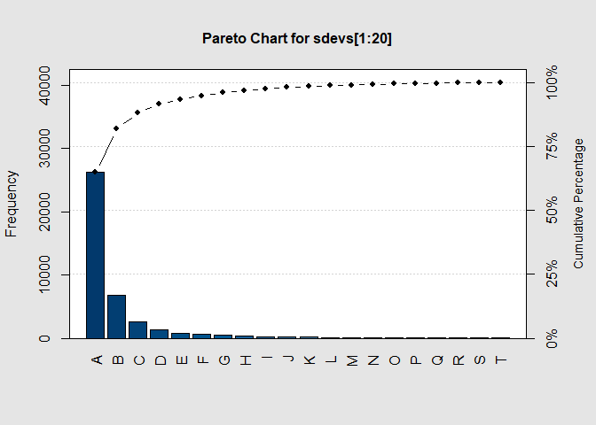

```
##
## Pareto chart analysis for sdevs[1:20]
##        Frequency    Cum.Freq.   Percentage Cum.Percent.
##   A 2.618904e+04 2.618904e+04 6.482333e+01 6.482333e+01
##   B 6.859681e+03 3.304872e+04 1.697914e+01 8.180247e+01
##   C 2.578502e+03 3.562722e+04 6.382330e+00 8.818480e+01
##   D 1.324281e+03 3.695150e+04 3.277871e+00 9.146267e+01
##   E 7.339513e+02 3.768545e+04 1.816682e+00 9.327935e+01
##   F 6.378868e+02 3.832334e+04 1.578903e+00 9.485826e+01
##   G 4.434811e+02 3.876682e+04 1.097708e+00 9.595596e+01
##   H 3.667795e+02 3.913360e+04 9.078558e-01 9.686382e+01
##   I 2.781774e+02 3.941178e+04 6.885470e-01 9.755237e+01
##   J 2.009872e+02 3.961276e+04 4.974852e-01 9.804985e+01
##   K 1.529680e+02 3.976573e+04 3.786276e-01 9.842848e+01
##   L 1.245236e+02 3.989026e+04 3.082218e-01 9.873670e+01
##   M 1.090750e+02 3.999933e+04 2.699833e-01 9.900668e+01
##   N 7.891490e+01 4.007825e+04 1.953308e-01 9.920202e+01
##   O 7.365470e+01 4.015190e+04 1.823107e-01 9.938433e+01
##   P 6.608237e+01 4.021798e+04 1.635676e-01 9.954789e+01
##   Q 5.409846e+01 4.027208e+04 1.339050e-01 9.968180e+01
##   R 4.621179e+01 4.031829e+04 1.143838e-01 9.979618e+01
##   S 4.418487e+01 4.036248e+04 1.093668e-01 9.990555e+01
##   T 3.815868e+01 4.040064e+04 9.445070e-02 1.000000e+02
```

[interactive chart not shown]

۶. با توجه به نمودار به دست آمده میتوان روز هایی از ماه که رفتار سهام مشابه بوده اند را گروه بندی کرد. یعنی رفتار سهام برخی روز ها مشابه هم است. این روز ها در نمودار نسبت به سایر روز ها در کنار هم قرار گرقته اند.

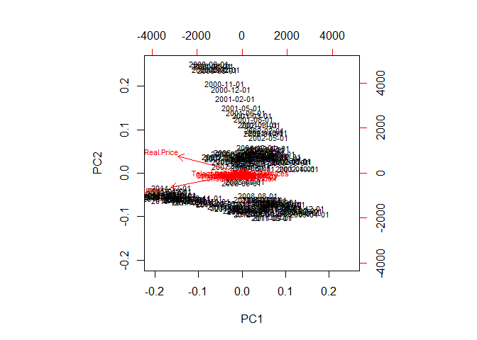

۷. با مقایسه این سوال با سوال 4 مشاهده میشود که مدل دقیق تر شده است.

[output not shown]

[interactive chart not shown]

```
## # A tibble: 1 x 2
##         .    er
##     <dbl> <int>
## 1 0.00226    15
```

۸. در این سوال از مدل h2o استفاده کردیم. همانطور که مشخص است دقت مدل حدود 70 درصد میباشد. درصد خطای پیش بینی نیز در زیر نوشته شده است.

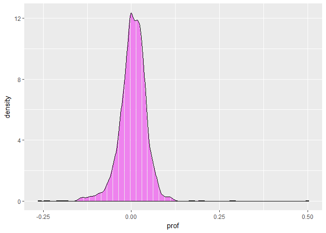

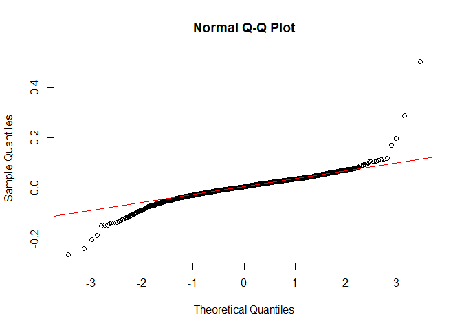

```
## Model Details:
## ==============
##
## H2OBinomialModel: glm
## Model ID:  GLM_model_R_1526742151095_39
## GLM Model: summary
##     family  link                               regularization
## 1 binomial logit Elastic Net (alpha = 0.5, lambda = 0.03607 )
##   number_of_predictors_total number_of_active_predictors
## 1                          5                           2
##   number_of_iterations training_frame
## 1                    4     sp500_open
##
## Coefficients: glm coefficients
##       names coefficients standardized_coefficients
## 1 Intercept     1.712090                  1.305516
## 2         A     0.000000                  0.000000
## 3       AAL     0.000000                  0.000000
## 4       AAP     0.000000                  0.000000
## 5      AAPL     0.005127                  0.920734
## 6      ABBV    -0.029052                 -0.267731
##
## H2OBinomialMetrics: glm
## ** Reported on training data. **
##
## MSE:  0.1628481
## RMSE:  0.4035444
## LogLoss:  0.4711359
## Mean Per-Class Error:  0.5
## AUC:  0.7159091
## Gini:  0.4318182
## R^2:  0.1672541
## Residual Deviance:  28.26815
## AIC:  34.26815
##
## Confusion Matrix (vertical: actual; across: predicted) for F1-optimal threshold:
##        0  1    Error   Rate
## 0      0  8 1.000000   =8/8
## 1      0 22 0.000000  =0/22
## Totals 0 30 0.266667  =8/30
```

[output cut: 64 more lines]

```
## ---
##                           mean          sd cv_1_valid cv_2_valid
## precision            0.7809524  0.09184429 0.85714287 0.71428573
## r2                -0.064406976   0.2532274 -0.7610022 0.09487851
## recall                    0.96  0.05656854        1.0        1.0
## residual_deviance    6.5500865   1.3164474   8.334252  7.3876643
## rmse                0.44095403 0.019151269 0.46436292  0.4297891
## specificity                0.2  0.28284273        0.0        0.0
##                     cv_3_valid cv_4_valid cv_5_valid
## precision            0.6666667        1.0  0.6666667
## r2                -0.036720395  0.1905407 0.19026849
## recall                     1.0        0.8        1.0
## residual_deviance    7.6069846   6.378446  3.0430853
## rmse                0.47998157 0.40644282 0.42419374
## specificity                0.0        1.0        0.0
```

تعداد مولفه ها برای فشرده سازی عکس را 35 در نظر گرفتیم. مشاهده میشود که حجم عکس 0.8 شده است.

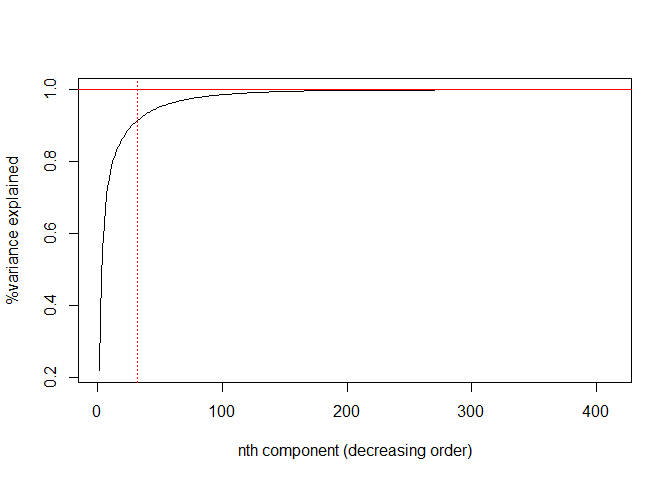

```
##              PC1        PC2         PC3         PC4           PC5
##  [1,] 0.04035857 0.09273267 -0.01630513 -0.02508326 -0.0182812531
##  [2,] 0.04081302 0.09367000 -0.01551049 -0.02526751 -0.0159406496
##  [3,] 0.04067542 0.09456438 -0.01410791 -0.02561947 -0.0129937553
##  [4,] 0.04070241 0.09544971 -0.01295522 -0.02511381 -0.0105548420
##  [5,] 0.04101744 0.09642098 -0.01242349 -0.02452928 -0.0076653696
##  [6,] 0.04160811 0.09757106 -0.01268120 -0.02367353 -0.0052176420
##  [7,] 0.04193975 0.09852460 -0.01231825 -0.02334508 -0.0027774586
##  [8,] 0.04199969 0.09927929 -0.01166876 -0.02249431 -0.0001522483
##  [9,] 0.04203073 0.09959990 -0.01115595 -0.02189766  0.0031456320
## [10,] 0.04213732 0.09963464 -0.01029879 -0.02087100  0.0066484515
```

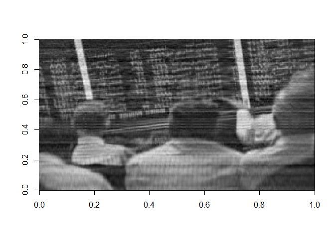

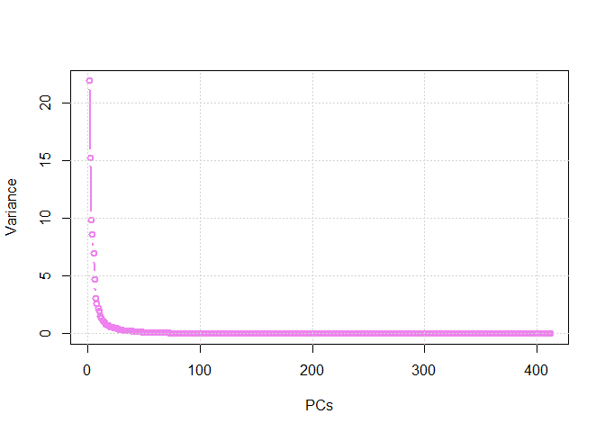

```r
library(jpeg)
writeJPEG(approx.img, "p.jpg")
(file.info("p.jpg")$size / 1000) / (file.info("../data/stock.jpg")$size / 1000) * 100
```

```
## [1] 79.22485
```

میتوان شرکت های رقیب را پیدا کرد. دو شرکت رقیب محسوب میشوند اگر زمان رکود سهام یکی، برابر با زمان صعود سهام دیگری باشد.

پیدا کردن شرکت هایی که از سیاست اقتصادی یکسانی استفاده میکنند.

10 شرکت اولی که بیشترین گردش مالی سالیانه را در 5 سال اخیر دارند.

کدام شرکت ها در طی سال های داده شده در لبه پرتگاه ورشکستگی قرار داشتند.

نمایش تغییرات مبادلات انجام شده برای هر بخش در طی سال های داده شده، اوج شکوفایی هر بخش کدام سال است؟